# assignment

Rebecca Waag

12 5 2023

# Week10: From repression to expression and back

## Exercise10: Clustering genomic signals and characterizing the clusters

Use clustering and visualization to illustrate the relationship between the binding of the different Creb proteins. Use enrichment analysis (either GO or motif) on at least one of the clusters. Focus on high-confidence peaks from each factor to define the universe of regions.

```r
#load libraries
suppressPackageStartupMessages({
  library(GenomicRanges)
  library(epiwraps)
  library(ggplot2)
  library(rGREAT) #find nearby genes, depending on distance from region
})
```

### Load data

```r
#specify working directory
setwd("/mnt/bohacek/rebecca/training/Bioinformatic Approaches Epigenomics/week10_assignment")

#download data
options(timeout = 6000)
download.file("https://ethz-ins.org/content/w10.assignment.zip", "w10.assignment.zip")
#unzip
unzip("w10.assignment.zip")
list.files()
```

### Prepare regions and tracks

```r
#specify working directory
setwd("/mnt/bohacek/rebecca/training/Bioinformatic Approaches Epigenomics/week10_assignment")

#read in bw file names
tracks <- list.files(pattern="bw$")
tracks
```

```
## [1] "Creb1.bw"   "Creb3.bw"   "Creb3L1.bw"
```

```r
#read in bed file names
peaks <- list.files(pattern="bed$")
peaks
```

```
## [1] "Creb1.bed"   "Creb3.bed"   "Creb3L1.bed"
```

```r
#import peaks
peaks <- lapply(peaks, rtracklayer::import.bed)
# focus on the high-quality peaks only
peaks <- lapply(peaks, FUN=function(x) x[x$score>800]) #restrict peaks to those with score >800
# obtain union of non-redundant regions
regions <- reduce(unlist(GRangesList(peaks)))
regions #GRanges with 2269 ranges, restricted to chr1
```

```
## GRanges object with 2269 ranges and 0 metadata columns:
##          seqnames              ranges strand
##             <Rle>           <IRanges>  <Rle>
##      [1]     chr1       778487-779069      *
##      [2]     chr1       904436-904985      *
##      [3]     chr1       941785-942096      *
##      [4]     chr1       943126-943501      *
##      [5]     chr1       959088-959463      *
##      ...      ...                 ...    ...
##   [2265]     chr1 248863011-248863586      *
##   [2266]     chr1 248873508-248874057      *
##   [2267]     chr1 248874114-248874382      *
##   [2268]     chr1 248905898-248906447      *
##   [2269]     chr1 248906637-248906839      *
##   -------
##   seqinfo: 1 sequence from an unspecified genome; no seqlengths
```

### Visualize signal across regions

```r
#plot heatmap
m_creb <- signal2Matrix(tracks, regions, extend=2000)
```

```
## Reading Creb1.bw
```

```
## Reading Creb3.bw
```

```
## Reading Creb3L1.bw
```

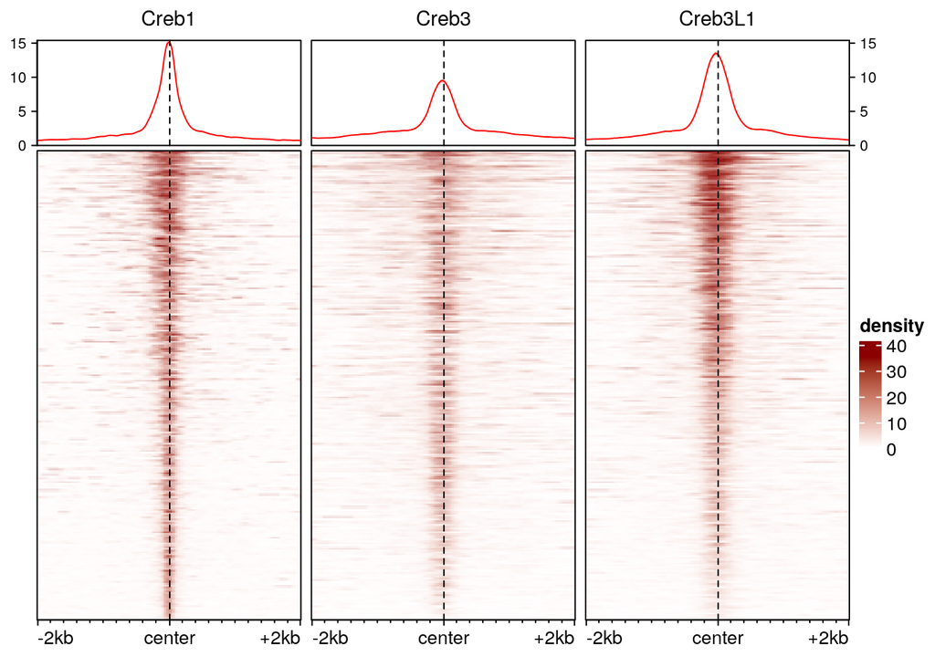

```r
plotEnrichedHeatmaps(m_creb, colors=c("white","darkred"))
```

All ChIPs show a signal in the union on non-redundant regions. However, no clear patterns are emerging due to the default ordering of regions.

### Cluster signal

Clustering of the signal is performed to reveal hidden patterns.

```r
#set seed to ensure reproducibility of clustering
set.seed(123)
#clustering signal with kmeans into 3 clusters, the relative signal instead of absolute values is used
cl_creb <- epiwraps::clusterSignalMatrices(m_creb, k=3, scaleRows=TRUE, seed=TRUE) #3 clusters explain 80% of variance
```

```
##   ~80% of the variance explained by clusters
```

```r
#add cluster information to the GRanges object
regions$clusters <- cl_creb
#regions
#compare number of regions in each cluster
table(cl_creb)
```

```
## cl_creb
##    1    2    3
##  442 1097  730
```

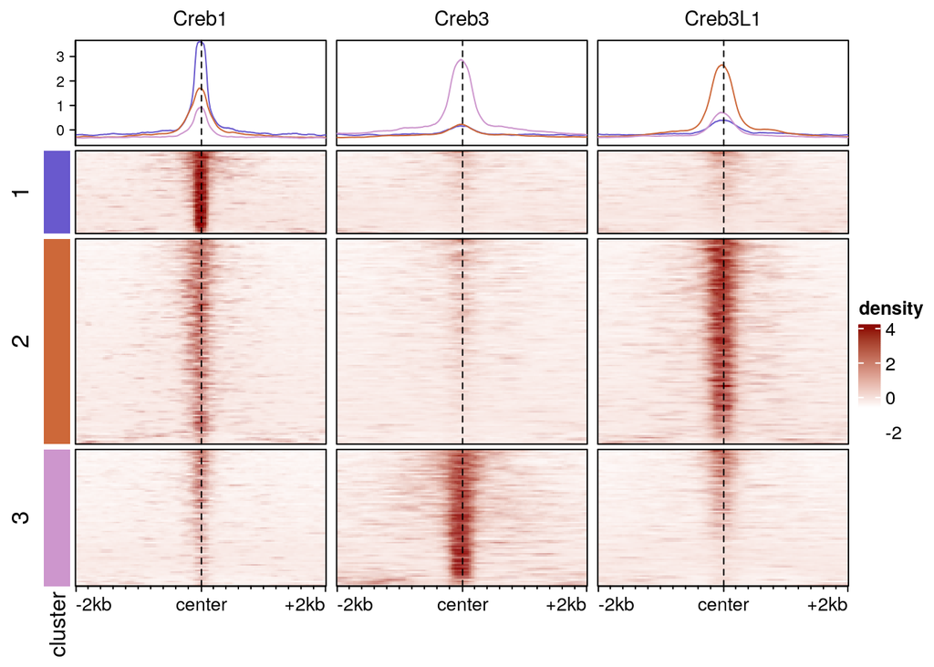

```r
#define colors for clusters
mycolors <-c("1"="slateblue3", "2"="sienna3", "3"="plum3")
#plot heatmap with clusters
plotEnrichedHeatmaps(m_creb, row_split=cl_creb, mean_color = mycolors, colors=c("white", "darkred"), scale_row="global")
```

Upon clustering using kmeans, clear patterns of Creb binding emerge. The strongest signal of Creb1 can be found in cluster 1, Creb3 shows the strongest signal in cluster 3 and Creb3L1 shows the strongest signal in cluster 2.

```r
#overlay for one cluster all of the marks
d<-meltSignals(m_creb, splitBy=cl_creb)
head(d)
```

```
##   split position sample      mean       SD         SE   median
## 1     1    -2000  Creb1 0.7693950 1.864104 0.08866640 0.296400
## 2     1    -1980  Creb1 0.7694042 1.941905 0.09236702 0.295925
## 3     1    -1960  Creb1 0.7923672 1.860622 0.08850078 0.298665
## 4     1    -1940  Creb1 0.7855034 1.665011 0.07919649 0.310555
## 5     1    -1920  Creb1 0.8048985 1.784694 0.08488922 0.322035
## 6     1    -1900  Creb1 0.8222276 1.825458 0.08682819 0.318560
```

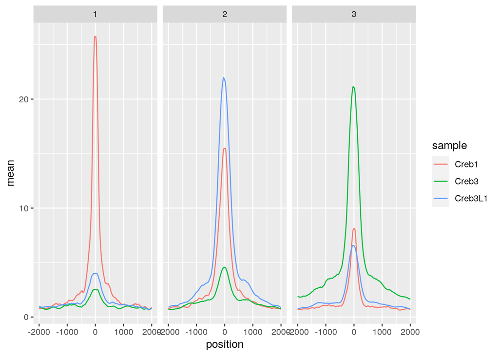

```r
ggplot(d, aes(position, mean, colour=sample))+geom_line() +facet_wrap(~split)
```

Each cluster of regions seems to be bound by all different Creb proteins, but to a different extent. Especially cluster 1 seems to predominantly contain regions that are bound by Creb1.

### Enrichment analysis

For enrichment analysis, I focus on cluster 1 which show a very strong signal of Creb1 binding.

```r
#split the regions by cluster
split_regions <- split(regions, cl_creb)

#send data to the GREAT server to run an enrichment analysis
job_1 <- rGREAT::submitGreatJob(gr=split_regions[["1"]], bg=regions, species="hg38")
res_1 <- rGREAT::getEnrichmentTables(job_1)
```

```
## The default enrichment tables contain no associated genes for the input
## regions. You can set `download_by = 'tsv'` to download the complete
## table, but note only the top 500 regions can be retreived. See the
## following link:
##
## https://great-help.atlassian.net/wiki/spaces/GREAT/pages/655401/Export#Export-GlobalExport
```

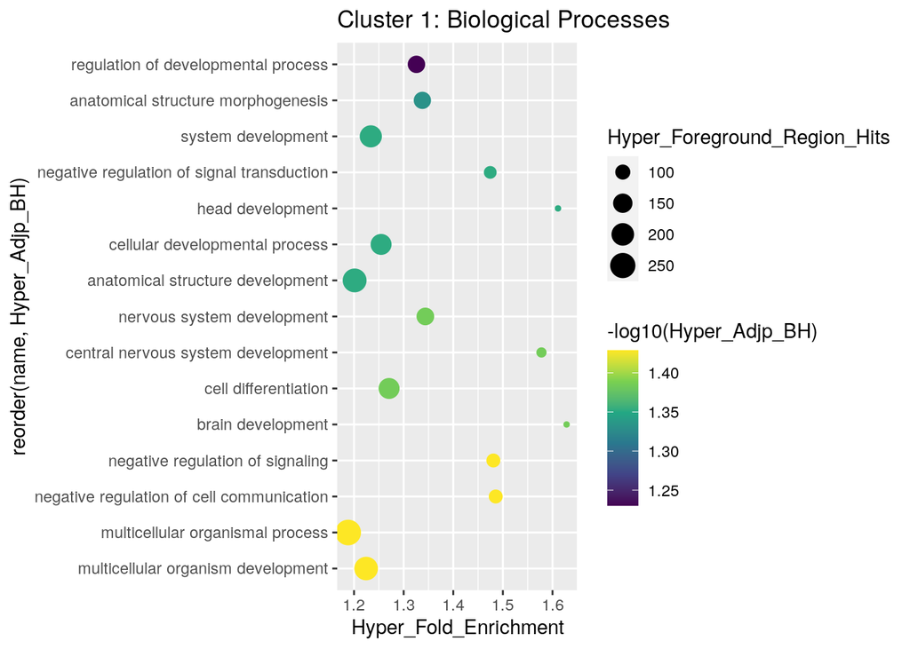

```r
#names(res_1)

#plot the top Biological Processes
bp_1 <- res_1$`GO Biological Process`
#head(bp_1)
ggplot(head(bp_1,15), aes(Hyper_Fold_Enrichment, reorder(name, Hyper_Adjp_BH), size=Hyper_Foreground_Region_Hits, color=-log10(Hyper_Adjp_BH))) + geom_point() + scale_color_viridis_c() + ggtitle("Cluster 1: Biological Processes")
```

We repeat the the enrichment analysis for cluster 3 that showed the strongest signal for Creb3.

```r
#send data to the GREAT server to run an enrichment analysis
job_3 <- rGREAT::submitGreatJob(gr=split_regions[["3"]], bg=regions, species="hg38")
```

```
## Don't make too frequent requests. The time break is 60s.
## Please wait for 49s for the next request.
## The time break can be set by `request_interval` argument.
```

```r
res_3 <- rGREAT::getEnrichmentTables(job_3)
```

```
## The default enrichment tables contain no associated genes for the input
## regions. You can set `download_by = 'tsv'` to download the complete
## table, but note only the top 500 regions can be retreived. See the
## following link:
##
## https://great-help.atlassian.net/wiki/spaces/GREAT/pages/655401/Export#Export-GlobalExport
```

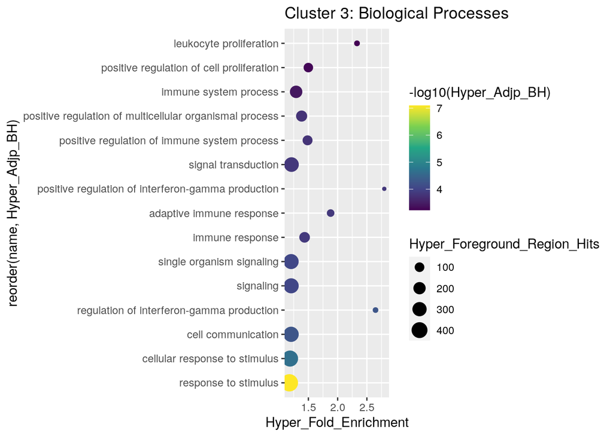

```r
#names(res_3)

#plot the top Biological Processes
bp_3 <- res_3$`GO Biological Process`
#head(bp_3)
ggplot(head(bp_3,15), aes(Hyper_Fold_Enrichment, reorder(name, Hyper_Adjp_BH), size=Hyper_Foreground_Region_Hits, color=-log10(Hyper_Adjp_BH))) + geom_point() + scale_color_viridis_c() + ggtitle("Cluster 3: Biological Processes")
```

Cluster 3 shows very different enrichment results, with the most interesting ones being (positive) regulation of interferon-gamma production.